# Evaluación continua de la primera parte

```r
#LIBRERIAS
library(ggplot2)
library(dplyr)
library(tibble)
library(ggrepel)
library(MASS)
# DATA
world2016 <- read.csv("data/data-world2016.csv",header=TRUE,dec=".",sep=",")
attach(world2016)
```

# EJERCICIO 3

### (a)

Encuentre los países con las diez distancias Mahalanobis más altas y las diez más bajas en el ejemplo anterior.

```r
data.for.mahalanobis=data.frame(log.GDP.percapita,life.expectancy)
M <- colMeans(data.for.mahalanobis)
S <- cov(data.for.mahalanobis)
mahalanobis.distances.2 <- apply(data.for.mahalanobis,
                                 1,
                                 mahalanobis,
                                 center=M,
                                 cov=S)
mahalanobis.distances <- sqrt(mahalanobis.distances.2)
dist_mah = cbind.data.frame(country,mahalanobis.distances,income.level.code)
# 10 distancias más altas
dist_mah[order(-dist_mah$mahalanobis.distances),][1:10,]
```

|  | country | mahalanobis.distances | income.level.code |
| --- | --- | --- | --- |
| 50 | Equatorial Guinea | 4.044815 | UM |
| 116 | Nigeria | 3.514675 | LM |
| 39 | Cote d'Ivoire | 3.157748 | LM |
| 142 | Sierra Leone | 2.731285 | L |
| 52 | Eswatini | 2.725178 | LM |
| 90 | Lesotho | 2.710485 | LM |
| 32 | Chad | 2.677865 | L |
| 31 | Central African Republic | 2.579356 | L |
| 154 | Tajikistan | 2.239579 | LM |
| 94 | Luxembourg | 2.212790 | H |

```r
# 10 distancias más bajas
dist_mah[order(dist_mah$mahalanobis.distances),][1:10,]
```

|  | country | mahalanobis.distances | income.level.code |
| --- | --- | --- | --- |
| 92 | Libya | 0.04726245 | UM |
| 135 | Saint Vincent and the Grenadines | 0.24463866 | UM |
| 151 | Suriname | 0.26768959 | UM |
| 46 | Dominican Republic | 0.29653961 | UM |
| 17 | Belize | 0.30007232 | UM |
| 105 | Mongolia | 0.31046037 | LM |
| 73 | Indonesia | 0.31638665 | LM |
| 104 | Federated States of Micronesia | 0.31988956 | LM |
| 20 | Bolivia | 0.32747595 | LM |
| 75 | Iraq | 0.34790394 | UM |

### (b)

Construya un diagrama de caja de las distancias de Mahalanobis según el nivel de ingresos e identifique los países correspondientes a los valores atípicos de cada grupo.

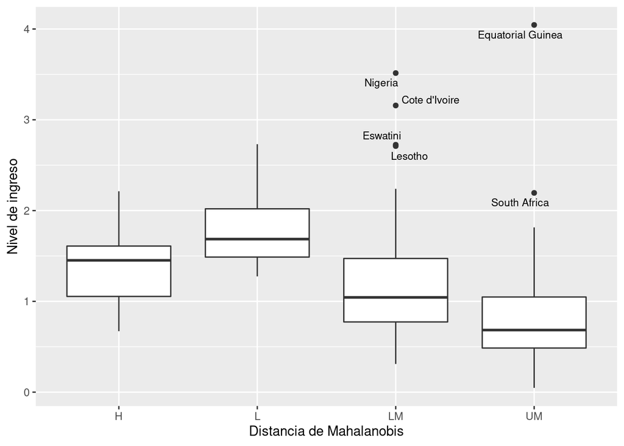

```r
is_outlier <- function(x) {
  return(x < quantile(x, 0.25)-1.5*IQR(x) | x>quantile(x,0.75)+1.5*IQR(x))
}

dat <- dist_mah %>% tibble::rownames_to_column(var="outlier") %>%
  group_by(income.level.code) %>%
  mutate(is_outlier=ifelse(is_outlier(mahalanobis.distances),
                           country, as.character(NA)))

ggplot(dat,
       aes(y=mahalanobis.distances, x=factor(income.level.code))) +
  geom_boxplot() +
  geom_text_repel(aes(label=is_outlier),
            na.rm=TRUE,
            size = 3
            ) +
  labs(x="Distancia de Mahalanobis", y = "Nivel de ingreso")
```

# EJERCICIO 4

Considere el marco de datos que consta de las variables (life.expectancy) esperanza de vida, (fertility.rate) tasa de fertilidad, (mortality.rate) tasa de mortalidad, (pop.growth) crecimiento de la población, (pop.rural) población rural y log.PIB.percapita del conjunto de datos world2016. Calcule las distancias de Mahalanobis de todos los países con respecto al vector de medias. Analizar y comentar los resultados obtenidos.

```r
data.for.mahalanobis = data.frame(life.expectancy,
                                  fertility.rate,
                                  mortality.rate,
                                  pop.growth,
                                  pop.rural,
                                  log.GDP.percapita)
M <- colMeans(data.for.mahalanobis)
S <- cov(data.for.mahalanobis)
mahalanobis.distances.2 <- apply(data.for.mahalanobis,
                                 1,
                                 mahalanobis,
                                 center=M,
                                 cov=S)
mahalanobis.distances <- sqrt(mahalanobis.distances.2)
dist_mah = cbind.data.frame(country,mahalanobis.distances)
# 10 distancias más altas
dist_mah[order(-dist_mah$mahalanobis.distances),][1:10,]
```

|  | country | mahalanobis.distances |
| --- | --- | --- |
| 118 | Oman | 5.282665 |
| 50 | Equatorial Guinea | 4.742556 |
| 31 | Central African Republic | 4.655907 |
| 115 | Niger | 4.318424 |
| 119 | Pakistan | 4.310945 |
| 90 | Lesotho | 4.262476 |
| 160 | Trinidad and Tobago | 4.260307 |
| 12 | Bahrain | 4.055563 |
| 136 | Samoa | 3.969898 |
| 128 | Qatar | 3.907124 |

```r
# 10 distancias más bajas
dist_mah[order(dist_mah$mahalanobis.distances),][1:10,]
```

|  | country | mahalanobis.distances |
| --- | --- | --- |
| 123 | Paraguay | 0.7988451 |
| 162 | Turkey | 1.0592440 |
| 34 | China | 1.1206764 |
| 151 | Suriname | 1.1594618 |
| 64 | Guatemala | 1.1762712 |
| 84 | Kiribati | 1.1940025 |
| 20 | Bolivia | 1.2396170 |
| 47 | Ecuador | 1.2873331 |
| 125 | Philippines | 1.2904152 |
| 48 | Egypt | 1.3227492 |

RESPUESTA.- A diferencia del anterior ejercicio vemos que al utilizar las variables: - esperanza de vida, - tasa de fertilidad, - tasa de mortalidad, - crecimiento de la población, - población rural y  
- logaritmno del pib per cápita

la distancia de Mahalanobis cambia y por ende cambia los paises que tiene mayor y menor distancia. Por ejemplo Oman esta más alejado del vector de medias y Paraguay es el que está más cerca se encuentra.’

# EJERCICIO 5

Considere el conjunto de datos world2016. Realice un PCA al conjunto de variables (life.expectancy) esperanza.vida, (fertility.rate) tasa.fecundidad, (mortality.rate) tasa.mortalidad, (pop.growth) crecimiento.población, (pop.rural) población.rural, log.PIB.percapita y (GDP.growth) crecimiento.PIB.’

```r
pca_data = data.frame(country,
                      life.expectancy,
                      fertility.rate,
                      mortality.rate,
                      pop.growth,
                      pop.rural,
                      log.GDP.percapita,
                      GDP.growth)

pca = pca_data[,2:8]
```

### (a)

¿Realizaría el PCA con base en la matriz de varianza-covarianza o en la matriz de correlación?

```r
# Matriz de correlaciones estandarizada
pca_world = princomp(pca,cor=TRUE)
# Resumen
summary(pca_world)
```

```
## Importance of components:
##                           Comp.1    Comp.2    Comp.3     Comp.4     Comp.5
## Standard deviation     2.1006426 1.0028800 0.9287473 0.60083793 0.42051210
## Proportion of Variance 0.6303856 0.1436812 0.1232245 0.05157232 0.02526149
## Cumulative Proportion  0.6303856 0.7740668 0.8972913 0.94886359 0.97412508
##                            Comp.6      Comp.7
## Standard deviation     0.35479335 0.235044906
## Proportion of Variance 0.01798262 0.007892301
## Cumulative Proportion  0.99210770 1.000000000
```

```r
# autovectores
# Vemos las variables esta más relacionada cada componente principal
pca_world$loadings
```

```
##
## Loadings:
##                   Comp.1 Comp.2 Comp.3 Comp.4 Comp.5 Comp.6 Comp.7
## life.expectancy    0.451                0.386  0.211  0.184  0.750
## fertility.rate    -0.439         0.249                0.860
## mortality.rate    -0.446               -0.432 -0.378 -0.220  0.650
## pop.growth        -0.329         0.689  0.503        -0.402
## pop.rural         -0.335        -0.631  0.629 -0.298
## log.GDP.percapita  0.429         0.245        -0.848  0.117 -0.110
## GDP.growth                0.996
##
##                Comp.1 Comp.2 Comp.3 Comp.4 Comp.5 Comp.6 Comp.7
## SS loadings     1.000  1.000  1.000  1.000  1.000  1.000  1.000
## Proportion Var  0.143  0.143  0.143  0.143  0.143  0.143  0.143
## Cumulative Var  0.143  0.286  0.429  0.571  0.714  0.857  1.000
```

```r
# nuevo conjunto de datos
df_pca = data.frame(pca_data$country, pca_world$scores[,1:3])
```

RESPUESTA.- Realizaremos con la matriz de correlación $R$ ya que en la práctica tenderá a eliminar el efecto de las unidades de cada variables.

### (b)

¿Cuántos componentes principales son relevantes para describir este conjunto de variables? ¿Por qué?

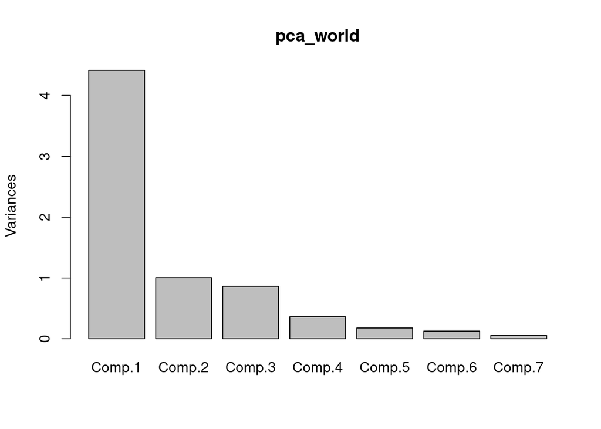

```r
screeplot(pca_world)
```

RESPUESTA.- Nos quedaremos con 3 componentes porque, la proporción acumulativa hasta el tercer componentes es del casi 90 %. También podemos ver este hecho si realizamos un gráfico de barras.

### (c)

Interprete los dos primeros componentes principales. Representar las puntuaciones correspondientes a los dos primeros componentes principales en un diagrama de dispersión y describir el resultado.

RESPUESTA.- Con respeto al primer componente vemos que mientras más alto es el es el valor de cada país entonces existe más esperanza de vida, menos tasa de fecundación, menos tasa de mortalidad y más PIB per cápita. Por ejemplo Japón encabeza la lista y el último es Chad. Con respecto a la segunda componente la única variable explicativa sería el crecimiento del PIB es decir a mayor valor mayor crecimiento.

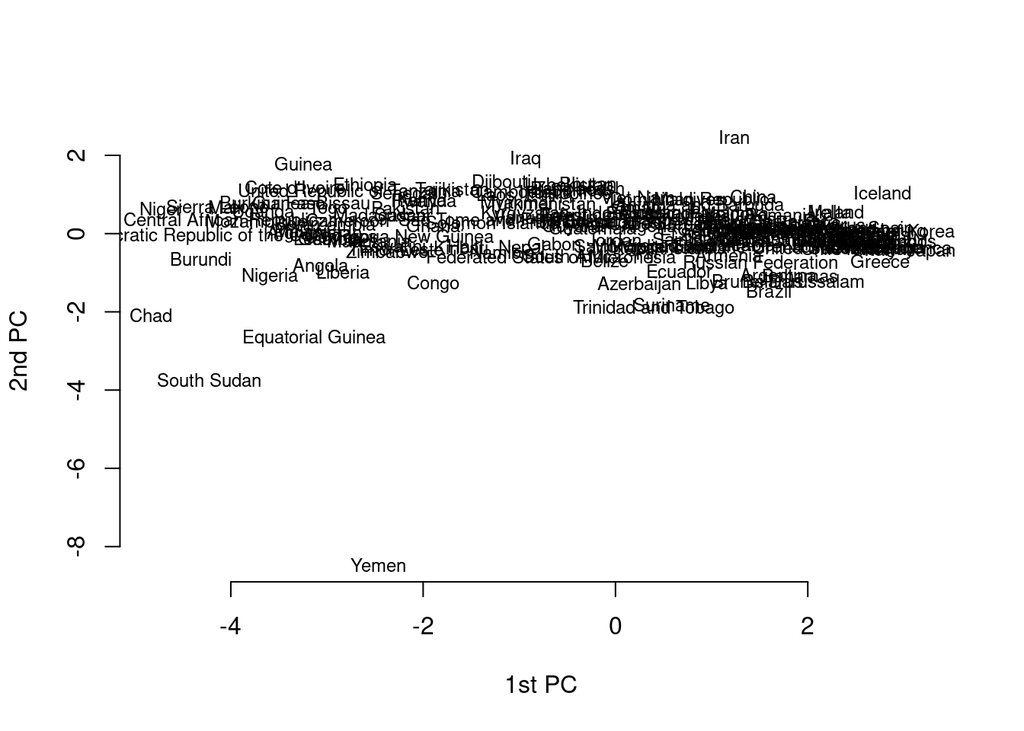

```r
plot(pca_world$scores[,1],
     pca_world$scores[,2],
     xlab="1st PC",
     ylab="2nd PC",
      type="n",frame=F)
text(pca_world$scores[,1],
     pca_world$scores[,2],
     pca_data$country,
     cex=0.75)
```

# EJERCICIO 8

Considere las siguientes siete variables del conjunto de datos world2016: life.expectancy, fertility.rate, mortality.rate, pop.growth, pop.rural, log.GDP.percapita y GDP.growth.

```r
fac_data = data.frame(country,
                      life.expectancy,
                      fertility.rate,
                      mortality.rate,
                      pop.growth,
                      pop.rural,
                      log.GDP.percapita,
                      GDP.growth)
```

### (a)

¿Cuál es el número máximo de factores permitidos en un modelo de análisis factorial con siete variables? ¿Cuántos factores deberían emplearse para explicar estas siete variables?

RESPUESTA.- El número máximo permitido será de 3 variables. Y se debería emplear 3 factores.

### (b)

Realice un análisis factorial con tres factores. Encuentre la comunalidad y la variabilidad específica para cada variable observada. Comente los resultados (preste especial atención a la variable GDP.growth

```r
factanal(fac_data[,2:8],factors=3)
```

```
##
## Call:
## factanal(x = fac_data[, 2:8], factors = 3)
##
## Uniquenesses:
##   life.expectancy    fertility.rate    mortality.rate        pop.growth
##             0.005             0.077             0.101             0.276
##         pop.rural log.GDP.percapita        GDP.growth
##             0.302             0.167             0.978
##
## Loadings:
##                   Factor1 Factor2 Factor3
## life.expectancy   -0.776  -0.508   0.367
## fertility.rate     0.543   0.792
## mortality.rate     0.697   0.568  -0.300
## pop.growth         0.171   0.833
## pop.rural          0.810   0.109   0.172
## log.GDP.percapita -0.821  -0.398
## GDP.growth                         0.148
##
##                Factor1 Factor2 Factor3
## SS loadings      2.744   2.073   0.277
## Proportion Var   0.392   0.296   0.040
## Cumulative Var   0.392   0.688   0.728
##
## Test of the hypothesis that 3 factors are sufficient.
## The chi square statistic is 2.2 on 3 degrees of freedom.
## The p-value is 0.532
```

RESPUESTA.- Vemos que la única variable que se queda sin explicar es GDP.growth Esto se reflja cuando analizamos las matrices de carga. Con respecto a las demás variables observamos que life.expectancy es la que más puede explicar seguido de fertility.rate. pop.rural se queda con un 30% sin explicar.

### (c)

Interpretar los factores obtenidos en términos de la matriz de cargas

# EJERCICIO 11

Considere el conjunto de datos world2016. Aplique el método de K-medias para crear grupos de países basados en las variables esperanza de vida, tasa de fertilidad, tasa de mortalidad, crecimiento de la población, población rural, log.PIB percapita y crecimiento del PIB. Compruebe si los países de la OCDE pertenecen al mismo grupo cuando se considera un número pequeño de grupos 2 o 3.

```r
k_data = data.frame(life.expectancy,
                      fertility.rate,
                      mortality.rate,
                      pop.growth,
                      pop.rural,
                      log.GDP.percapita,
                      GDP.growth)

km3 <- kmeans(k_data,3)
c=as.character(country)[km3$cluster==1]
as.character(country)[km3$cluster==2]
```

```
##  [1] "Albania"                          "Antigua and Barbuda"
##  [3] "Azerbaijan"                       "Bangladesh"
##  [5] "Barbados"                         "Belize"
##  [7] "Bhutan"                           "Botswana"
##  [9] "Cambodia"                         "China"
## [11] "Egypt"                            "Fiji"
## [13] "Georgia"                          "Grenada"
## [15] "Guatemala"                        "Guyana"
## [17] "Honduras"                         "India"
## [19] "Indonesia"                        "Jamaica"
## [21] "Kazakhstan"                       "Kyrgyzstan"
## [23] "Madagascar"                       "Maldives"
## [25] "Mauritius"                        "Federated States of Micronesia"
## [27] "Morocco"                          "Namibia"
## [29] "Nepal"                            "Nicaragua"
## [31] "Paraguay"                         "Philippines"
## [33] "Republic of Moldova"              "Romania"
## [35] "Rwanda"                           "Saint Lucia"
## [37] "Saint Vincent and the Grenadines" "Samoa"
## [39] "Senegal"                          "Serbia"
## [41] "Seychelles"                       "Slovakia"
## [43] "Slovenia"                         "Solomon Islands"
## [45] "South Africa"                     "Sri Lanka"
## [47] "Thailand"                         "FYR Macedonia"
## [49] "Tonga"                            "Trinidad and Tobago"
## [51] "Uzbekistan"                       "Vanuatu"
## [53] "Viet Nam"
```

```r
as.character(country)[km3$cluster==3]
```

```
##  [1] "Algeria"                  "Argentina"
##  [3] "Armenia"                  "Australia"
##  [5] "Austria"                  "Bahamas"
##  [7] "Bahrain"                  "Belarus"
##  [9] "Belgium"                  "Bolivia"
## [11] "Brazil"                   "Brunei Darussalam"
## [13] "Bulgaria"                 "Canada"
## [15] "Cabo Verde"               "Chile"
## [17] "Colombia"                 "Costa Rica"
## [19] "Croatia"                  "Cyprus"
## [21] "Czechia"                  "Denmark"
## [23] "Dominican Republic"       "Ecuador"
## [25] "El Salvador"              "Estonia"
## [27] "Finland"                  "France"
## [29] "Gabon"                    "Germany"
```

[output cut: 23 more lines]

# EJERCICIO 13

Considere el conjunto de datos world2016.

### (a)

Considere dos clases de países: aquellos con ingresos “bajos” o “medios bajos” y aquellos con ingresos “medios altos” o “altos”. Cree una variable binaria para asignar cada país a uno de estos dos grupos.

```r
world2016 = mutate(world2016,
       ingreso = ifelse(income.level.code=="H" |
                          income.level.code=="UM","high","low"))
```

### (b)

Cree una regla de discriminación para clasificar los países en los dos grupos creados en (a) de acuerdo con las variables demográficas esperanza.vida, tasa.fecundidad, tasa.mortalidad, crecimiento.población y población.rural.

```r
attach(world2016)
```

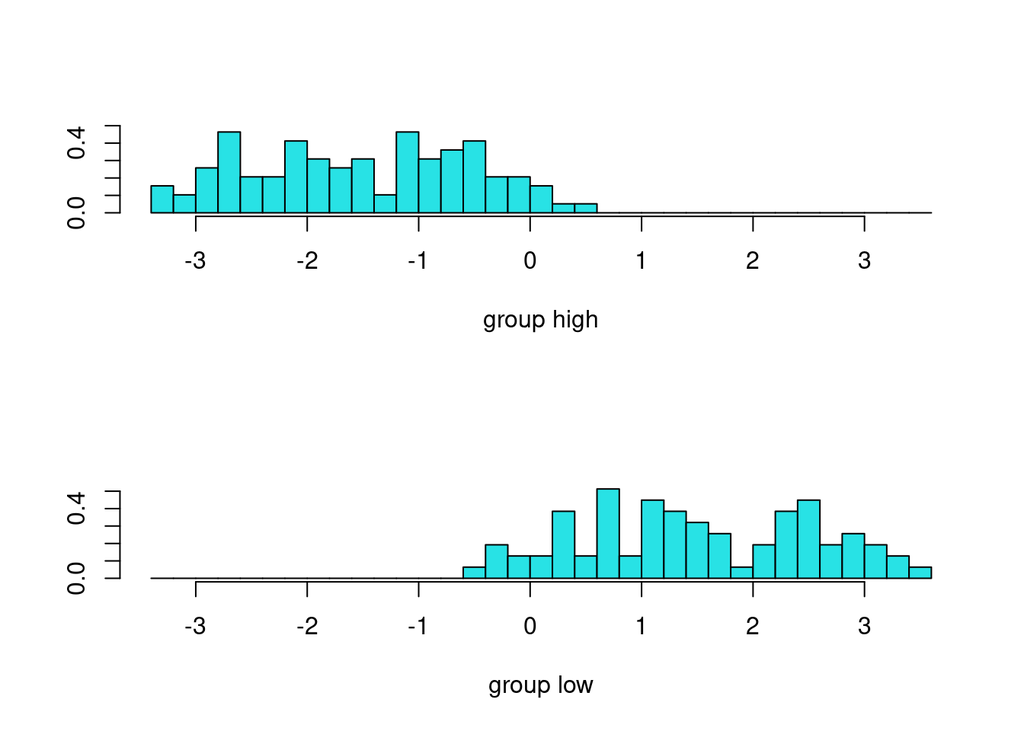

```r
dis_data = data.frame(life.expectancy,
                      fertility.rate,
                      mortality.rate,
                      pop.growth,
                      pop.rural,
                      log.GDP.percapita,
                      GDP.growth,
                      ingreso)
lda.word <- lda(ingreso~life.expectancy+
                  fertility.rate+
                  mortality.rate+pop.growth+
                  pop.rural+
                  log.GDP.percapita+
                  GDP.growth
                )
plot(lda.word)
```

### (c)

Encuentre la tabla de confusión basada en la validación cruzada. Discutir los resultados obtenidos.

```r
n <- length(ingreso)
predicted.class <- factor(rep(NA,n),levels=c("high","low"))
for (i in 1:n){
lda.cv <- lda(ingreso~life.expectancy+
                  fertility.rate+
                  mortality.rate+pop.growth+
                  pop.rural+
                  log.GDP.percapita+
                  GDP.growth, data=dis_data[-i,])
predicted.class[i] <- predict(lda.cv,dis_data[i,])$class
}
table(predicted.class,ingreso)
```

```
##                ingreso
## predicted.class high low
##            high   91   8
##            low     6  70
```

RESPUESTA.- Vemos que se tiene 6 falsos positivos y 8 falsos negativos. De los 175 datos (está claro que estos resultados pueden variar). Visto esto el modelo clasifica y/o predice a un 92%.